# Dublin Data Science Workshop on Survival Analysis

Section 2

Mick Cooney mickcooney@gmail.com

Monday, 24 September 2018

# 1 Estimations of the Survival Functions

## 1.1 The Kaplan-Meier Estimator

Kaplan-Meier is the standard method for estimating the survival function of a given dataset. Formally, it is defined as follows

$$\hat{S}(t) = \prod_{t_i \leq t} (1 - \hat{q}_i) = \prod_{t_i \leq t} \left(1 - \frac{d_i}{n_i}\right)$$

where $n_i$ is the number of subjects at risk at time $t$, and $d_i$ is the number of individuals who fail at that time.

### 1.1.1 Using Kaplan-Meier

In R, we construct KM estimators using the `survfit()` function.

Before we move on to our datasets, we start with a small set of data.

```r
tt   <- c(7, 6, 6, 5, 2, 4)
cens <- c(0, 1, 0, 0, 1, 1)

Surv(tt, cens)
```

```
## [1] 7+ 6  6+ 5+ 2  4
```

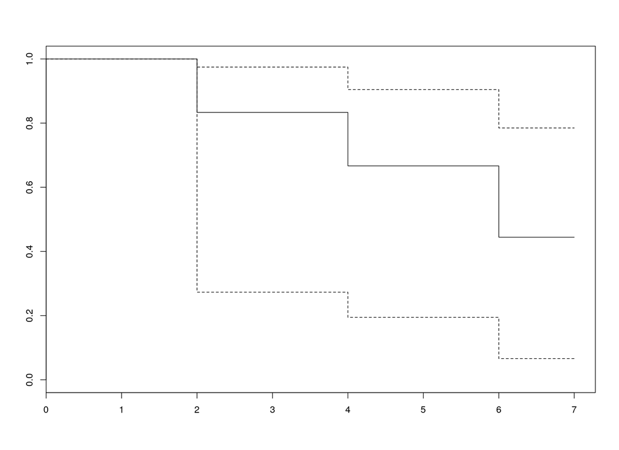

```r
sample_tbl <- data_frame(tt = tt, cens = cens)

example_km <- survfit(Surv(tt, cens) ~ 1, data = sample_tbl, conf.type = 'log-log')

plot(example_km)
```

Basic plotting routines are worth trying, but the `survminer` package has specialised plots that use `ggplot2` to create them.

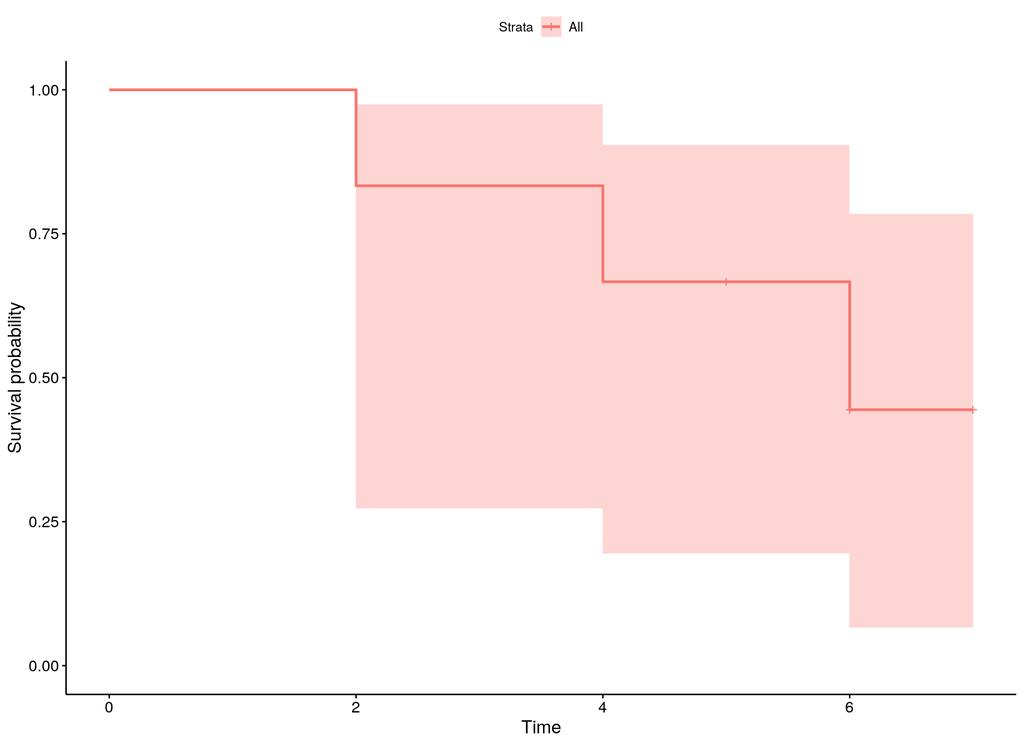

```r
ggsurvplot(example_km)
```

Printing out the ‘fitted’ object gives us some basic statistics:

```r
example_km %>% print()
```

```
## Call: survfit(formula = Surv(tt, cens) ~ 1, data = sample_tbl, conf.type = "log-log")
##
##       n  events  median 0.95LCL 0.95UCL
##       6       3       6       2      NA
```

We get more details from the `summary()` function:

```r
example_km %>% summary()
```

```
## Call: survfit(formula = Surv(tt, cens) ~ 1, data = sample_tbl, conf.type = "log-log")
##
##  time n.risk n.event survival std.err lower 95% CI upper 95% CI
##     2      6       1    0.833   0.152       0.2731        0.975
##     4      5       1    0.667   0.192       0.1946        0.904
##     6      3       1    0.444   0.222       0.0662        0.785
```

#### 1.1.1.1 Exercises

1. Construct the KM estimator for the telco churn data
2. What is the median survival time for this data?
3. What is the mean survival time?
4. Repeat the above for the other two datasets.

### 1.1.2 Follow-up Time

A useful measure may be how long the observation period lasts, something that can be subtly difficult to measure.

One method is to switch the censoring labels - that is, we consider the original event as a censoring of the observation in the study.

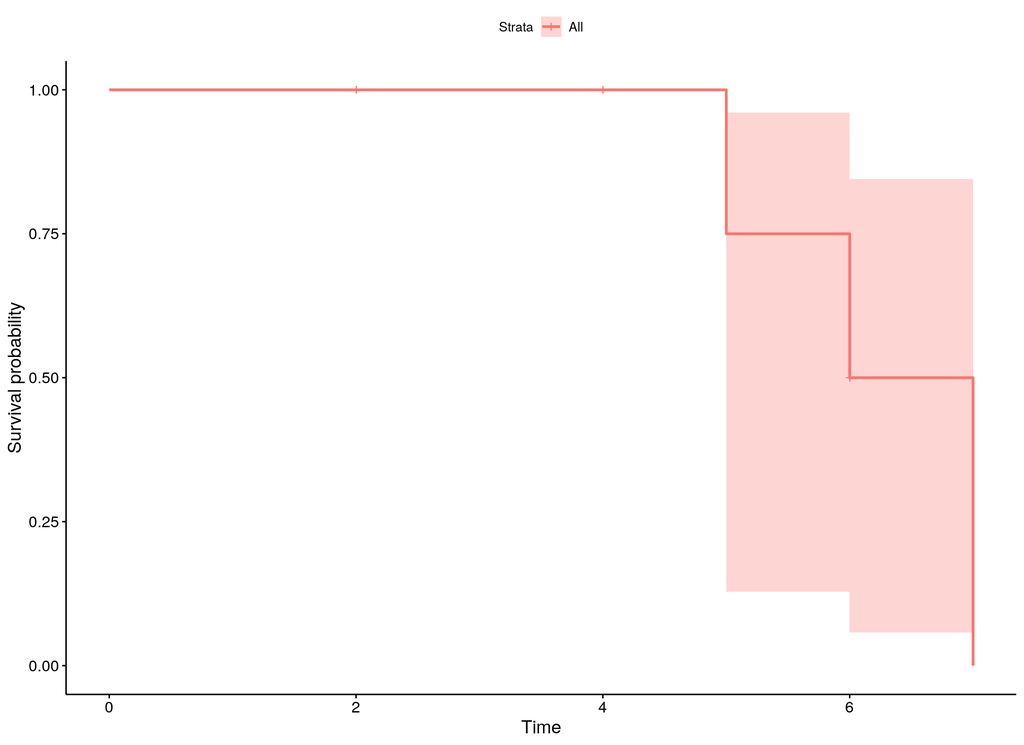

```r
sample_tbl <- sample_tbl %>%
    mutate(follow = 1 - cens)

follow_km <- survfit(Surv(tt, follow) ~ 1, data = sample_tbl, conf.type = 'log-log')

ggsurvplot(follow_km)
```

```r
follow_km %>% summary()
```

```
## Call: survfit(formula = Surv(tt, follow) ~ 1, data = sample_tbl, conf.type = "log-log")
##
##  time n.risk n.event survival std.err lower 95% CI upper 95% CI
##     5      4       1     0.75   0.217       0.1279        0.961
##     6      3       1     0.50   0.250       0.0578        0.845
##     7      1       1     0.00     NaN           NA           NA
```

## 1.2 Smoothed Hazard Functions

An empirical estimate of the hazard function is given by

$$\mu(i) = \frac{d_i}{n_i}$$

This is a very noisy estimate as it is sensitive to sample noise.

### 1.2.1 The Hazard Estimator

To obtain more smooth functions we use kernel density estimator techniques.

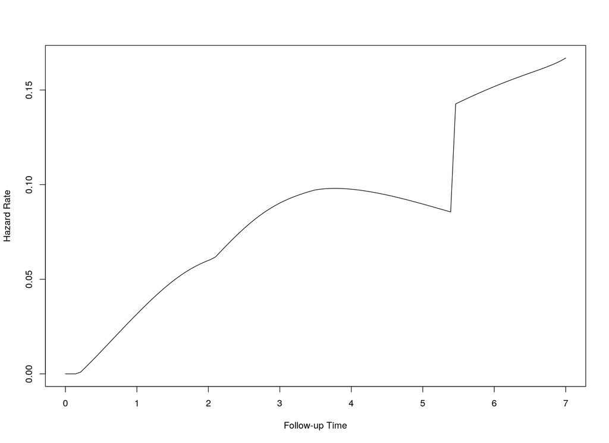

```r
sample_muhaz <- muhaz(sample_tbl$tt, sample_tbl$cens, max.time = 7)

plot(sample_muhaz)
```

`broom` has tidying methods for `muhaz()` and this allows us to create plots with `ggplot2`

```r
muhaz_tidy_tbl <- sample_muhaz %>% tidy()

muhaz_tidy_tbl %>% glimpse()
```

```
## Observations: 101
## Variables: 2
## $ time     <dbl> 0.00, 0.07, 0.14, 0.21, 0.28, 0.35, 0.42, 0.49, 0.56, 0.63...
## $ estimate <dbl> 0.000000000, 0.000000000, 0.000000000, 0.000871904, 0.0034...
```

We have estimates of the hazard function now and so can plot it.

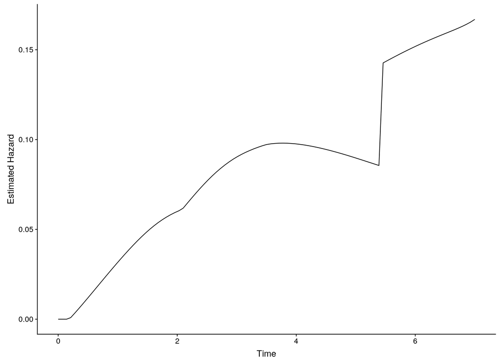

```r
ggplot(muhaz_tidy_tbl) +
    geom_line(aes(x = time, y = estimate)) +
    expand_limits(x = 0, y = 0) +
    xlab("Time") +
    ylab("Estimated Hazard")
```

#### 1.2.1.1 Exercises

1. Construct the smoothed estimator for the telco churn data
2. What time has the highest hazard rate?
3. What time has the lowest hazard rate?
4. Repeat the above for the other two datasets.

### 1.2.2 Boundary Corrections

By default, `muhaz()` corrects for the boundary on both sides, but we may not wish this. To get estimates without this correction, we add it as an argument to the function call.

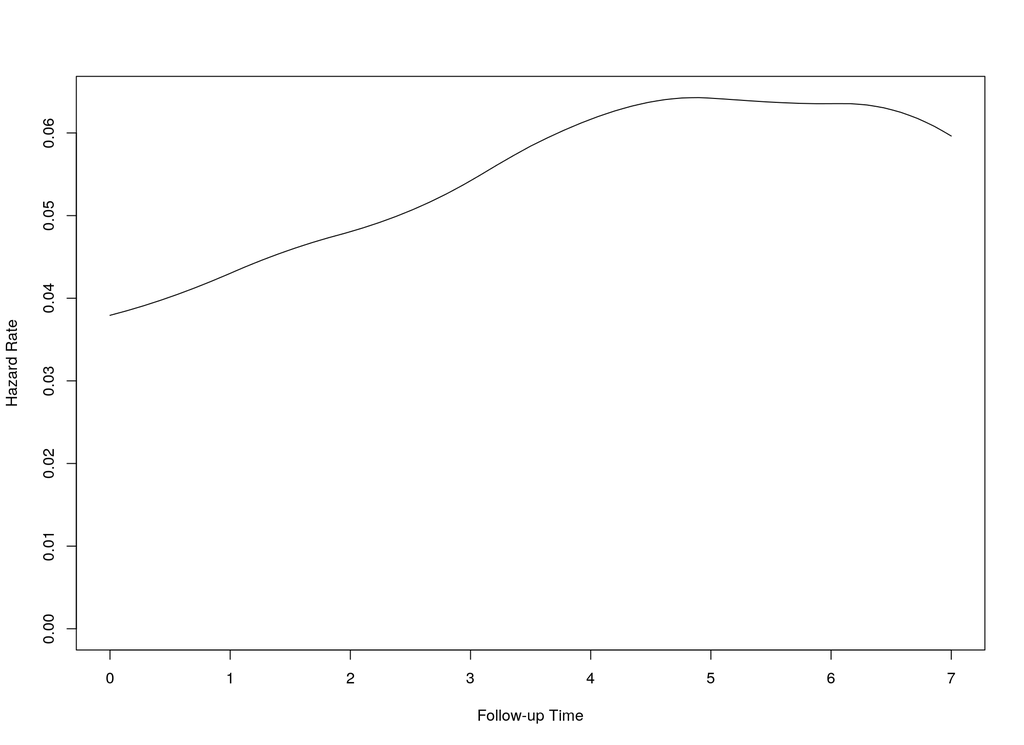

```r
sample_nocorr_muhaz <- muhaz(sample_tbl$tt, sample_tbl$cens, max.time = 7
                            ,b.cor = 'none')

plot(sample_nocorr_muhaz)
```

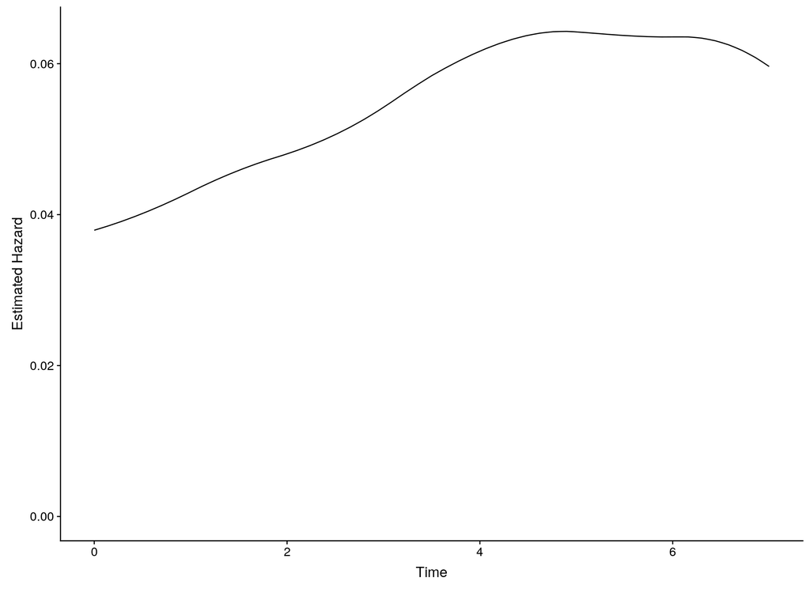

```r
sample_nocorr_muhaz_tidy_tbl <- sample_nocorr_muhaz %>% tidy()

ggplot(sample_nocorr_muhaz_tidy_tbl) +
    geom_line(aes(x = time, y = estimate)) +
    expand_limits(x = 0, y = 0) +
    xlab("Time") +
    ylab("Estimated Hazard")
```

To help ensure these smoothed estimates are capturing the correct aspects of the data, we also have the equivalent `pehaz()` functions - giving histogram estimates of the hazards, much how histogram and kernel estimates are discrete and continuous analogies of one another.

#### 1.2.2.1 Exercises

1. Construct the non-corrected smoothed estimator for the telco churn data
2. Repeat the above for the other two datasets.

## 1.3 Comparing KM and Smoothed Estimates

Now that we have both methods of checking the empirical estimates, it is good to compare them.

Before we do this, we note that Kaplan-Meier estimates the survival function but `muhaz()` gives us estimates of the hazard function.

Thus we need to do some conversions and the easiest way to do this is to numerically integrate the hazard functions to calculate the survival function and then compare to the KM estimate.

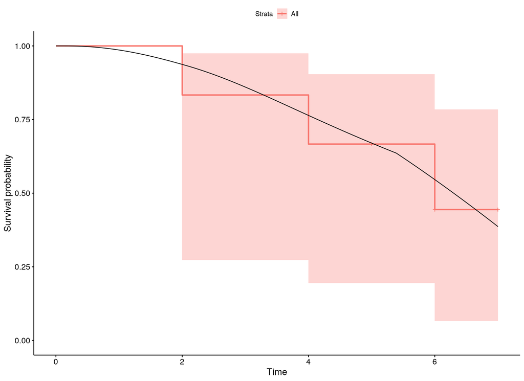

```r
muhaz_surv_tbl <- muhaz_tidy_tbl %>%
    mutate(dt  = c(0, diff(time))
          ,S_t = 1 - cumsum(estimate * dt))

ggsurvplot(example_km)$plot +
    geom_line(aes(x = time, y = S_t), data = muhaz_surv_tbl)
```

### 1.3.1 No Boundary Correction

We also want to compare the results without the boundary correction.

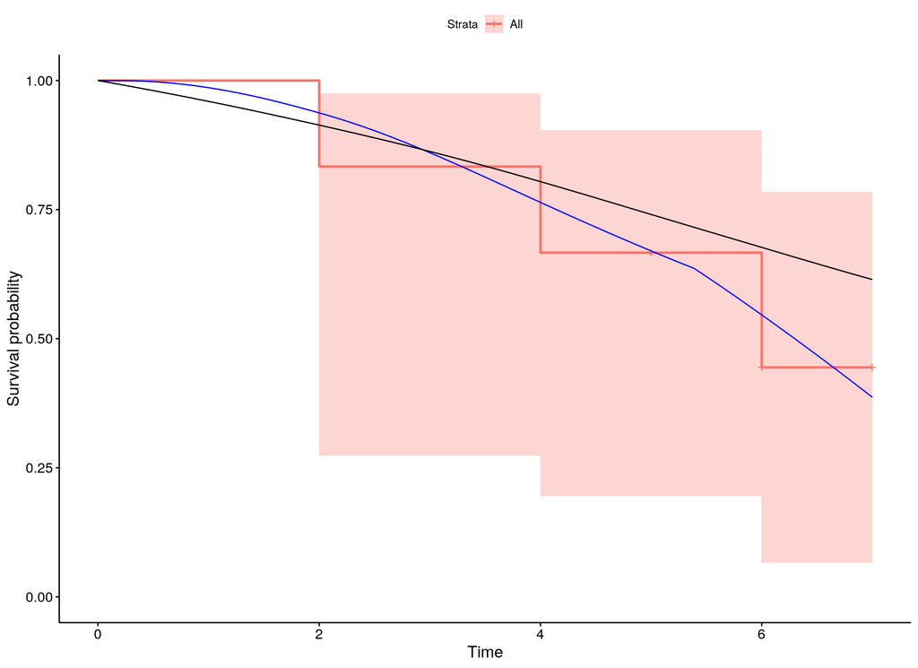

```r
muhaz_nocorr_surv_tbl <- sample_nocorr_muhaz_tidy_tbl %>%
    mutate(dt  = c(0, diff(time))
          ,S_t = 1 - cumsum(estimate * dt))

ggsurvplot(example_km)$plot +
    geom_line(aes(x = time, y = S_t), colour = 'blue', data = muhaz_surv_tbl) +
    geom_line(aes(x = time, y = S_t), data = muhaz_nocorr_surv_tbl)
```

We see that removing the boundary corrections can cause big discrepancies between the smoothed and discrete estimates (at least in this case)

```
##  setting  value
##  version  R version 3.5.1 (2018-07-02)
##  system   x86_64, linux-gnu
##  ui       X11
##  language en_US:en
##  collate  en_US.UTF-8
##  tz       Europe/Dublin
##  date     2018-09-22
```

```
## Packages ----------------------------------------------------------------------
```

[output not shown]

[output cut: 27 more lines]

[output not shown]